# 1 Explanatory Data Analysis

```r
data <- data.frame(readxl::read_xlsx("2019 Winter Data Science Intern Challenge Data Set.xlsx"))

summary(is.na(data)) %>% pander()
```

Table continues below

| order_id | shop_id | user_id | order_amount | total_items |
| --- | --- | --- | --- | --- |
| Mode :logical | Mode :logical | Mode :logical | Mode :logical | Mode :logical |
| FALSE:5000 | FALSE:5000 | FALSE:5000 | FALSE:5000 | FALSE:5000 |

| payment_method | created_at |
| --- | --- |
| Mode :logical | Mode :logical |
| FALSE:5000 | FALSE:5000 |

```r
summary(data) %>% pander()
```

Table continues below

| order_id | shop_id | user_id | order_amount |
| --- | --- | --- | --- |
| Min. : 1 | Min. : 1.00 | Min. :607.0 | Min. : 90 |
| 1st Qu.:1251 | 1st Qu.: 24.00 | 1st Qu.:775.0 | 1st Qu.: 163 |
| Median :2500 | Median : 50.00 | Median :849.0 | Median : 284 |
| Mean :2500 | Mean : 50.08 | Mean :849.1 | Mean : 3145 |
| 3rd Qu.:3750 | 3rd Qu.: 75.00 | 3rd Qu.:925.0 | 3rd Qu.: 390 |
| Max. :5000 | Max. :100.00 | Max. :999.0 | Max. :704000 |

| total_items | payment_method | created_at |
| --- | --- | --- |
| Min. : 1.000 | Length:5000 | Min. :2017-03-01 00:08:09 |
| 1st Qu.: 1.000 | Class :character | 1st Qu.:2017-03-08 07:08:04 |
| Median : 2.000 | Mode :character | Median :2017-03-16 00:21:20 |
| Mean : 8.787 | NA | Mean :2017-03-15 22:20:37 |
| 3rd Qu.: 3.000 | NA | 3rd Qu.:2017-03-23 10:39:57 |
| Max. :2000.000 | NA | Max. :2017-03-30 23:55:35 |

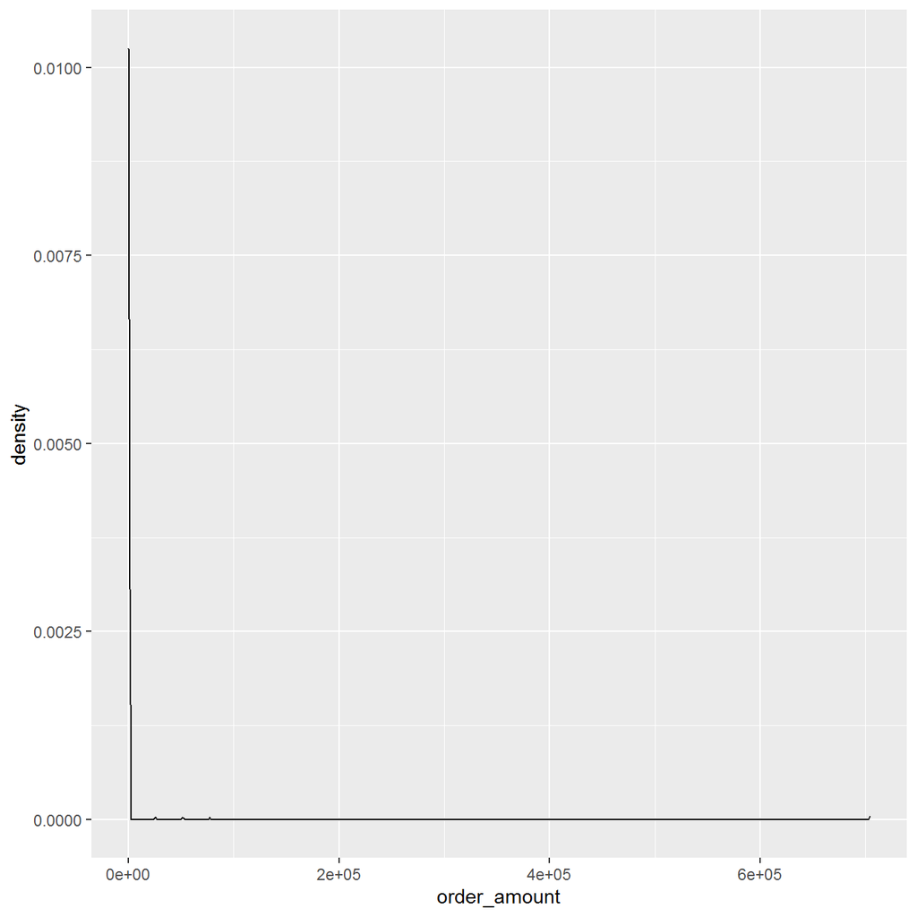

```r
ggplot(data, aes( x = order_amount)) + geom_density()
```

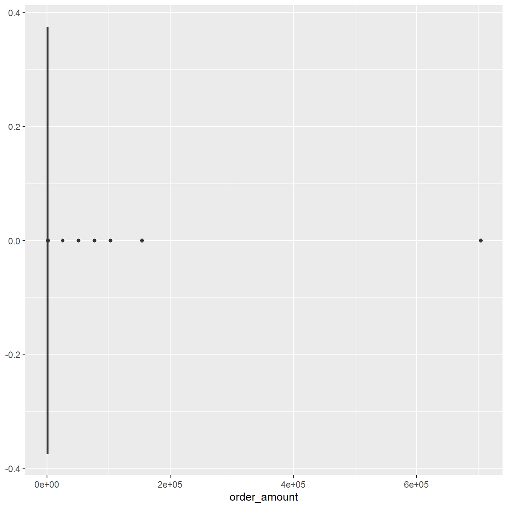

```r
ggplot(data, aes( x = order_amount)) + geom_boxplot()
```

$$\text{Average Order Value} = \text{Revenue} / \text{Number of Orders}$$

# 2 Outlier Elimination

Here, I eliminated orders that have extremely high order costs which is 704000 and the orders are taken from `shop_id` 78 since its products are way expensive that is 25725 than usual shoe prices.

```r
to_del = which(data$order_amount == 704000 | data$shop_id == 78)

new_data <- data[-to_del,]

summary(new_data) %>% pander()
```

Table continues below

| order_id | shop_id | user_id | order_amount | total_items |
| --- | --- | --- | --- | --- |
| Min. : 1 | Min. : 1.00 | Min. :700.0 | Min. : 90.0 | Min. :1.000 |
| 1st Qu.:1248 | 1st Qu.: 24.00 | 1st Qu.:775.0 | 1st Qu.: 163.0 | 1st Qu.:1.000 |
| Median :2497 | Median : 50.00 | Median :850.0 | Median : 284.0 | Median :2.000 |
| Mean :2500 | Mean : 49.85 | Mean :849.8 | Mean : 302.6 | Mean :1.995 |
| 3rd Qu.:3751 | 3rd Qu.: 74.00 | 3rd Qu.:925.0 | 3rd Qu.: 387.0 | 3rd Qu.:3.000 |
| Max. :5000 | Max. :100.00 | Max. :999.0 | Max. :1760.0 | Max. :8.000 |

| payment_method | created_at |
| --- | --- |
| Length:4937 | Min. :2017-03-01 00:08:09 |
| Class :character | 1st Qu.:2017-03-08 06:25:17 |
| Mode :character | Median :2017-03-15 23:23:27 |
| NA | Mean :2017-03-15 21:59:18 |
| NA | 3rd Qu.:2017-03-23 10:39:06 |
| NA | Max. :2017-03-30 23:55:35 |

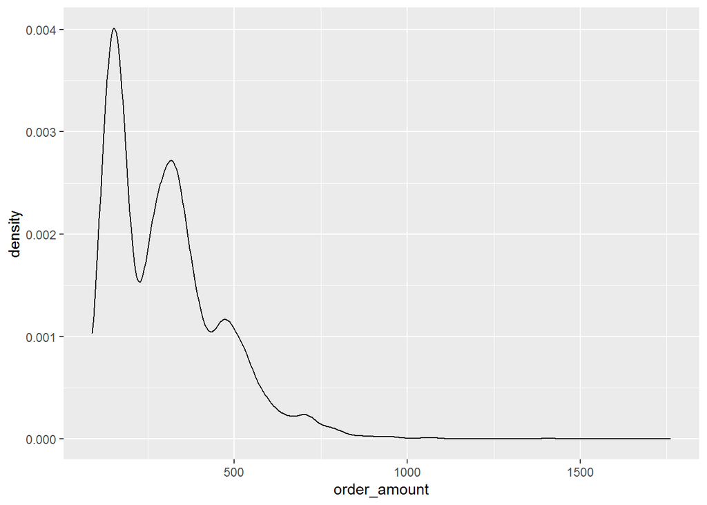

```r
ggplot(new_data, aes( x = order_amount)) + geom_density()
```

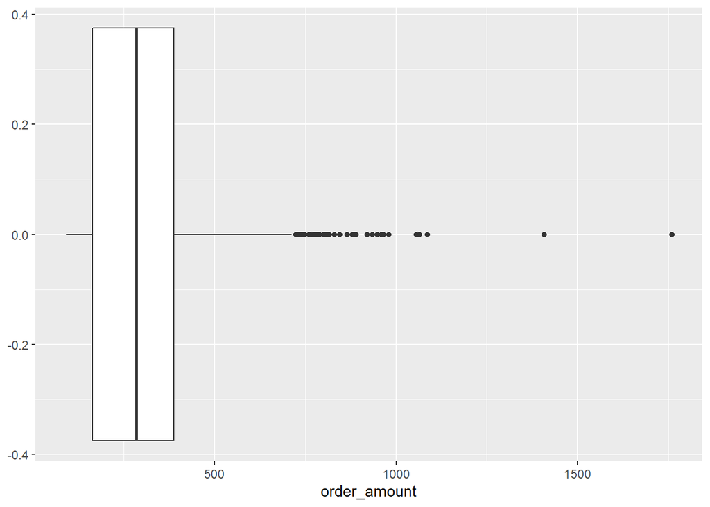

```r
ggplot(new_data, aes( x = order_amount)) + geom_boxplot()
```

The new Average Order Value is 302.6 according to my analysis

# 3 Questions

## 3.1 Think about what could be going wrong with our calculation. Think about a better way to evaluate this data.

By checking the dataset, I observed some outliers. This might be a problem while we are trying to calculate a mean value. There are no missing values which is good. As it can be a problem in the modelling phase and generalizable results, we should consider removing the outlier values by checking the quantile values. We can choose a threshold as .75 quantile.

## 3.2 What metric would you report for this dataset?

If we directly use average value, we might make mistakes. As I indicated in the first question, the mean value can be misleading. Instead, we can report several quantile (or percentile) values, such as .5, .25, .50, .75, .95.

## 3.3 What is its value?

Without outlier elimination,

```r
quantile(data$order_amount, c(.05, .25, .5, .75, .95)) %>% pander()
```

| 5% | 25% | 50% | 75% | 95% |
| --- | --- | --- | --- | --- |
| 122 | 163 | 284 | 390 | 640 |

With outlier elimination,

```r
quantile(new_data$order_amount, c(.05, .25, .5, .75, .95)) %>% pander()
```

| 5% | 25% | 50% | 75% | 95% |
| --- | --- | --- | --- | --- |
| 122 | 163 | 284 | 387 | 592 |